# Statistical Modelling of COVID-19 Outbreak in Italy

27 Mar 2020

# Nonlinear growth models

Nonlinear growth models represent an instance of *nonlinear regression models*, a class of models taking the general form
$$y = \mu(x, \theta) + \epsilon,$$
where $\mu(x, \theta)$ is the mean function which depends on a possibly vector-valued parameter $\theta$, and a possibly vector-valued predictor $x$. The stochastic component $\epsilon$ represents the error with mean zero and constant variance. Usually, a Gaussian distribution is also assumed for the error term.

By defining the mean function $\mu(x, \theta)$ we may obtain several different models, all characterized by the fact that parameters $\theta$ enter in a nonlinear way into the equation. Parameters are usually estimated by *nonlinear least squares* which aims at minimizing the residual sum of squares.

## Exponential

$$\mu(x) = \theta_1 \exp\{\theta_2 x\}$$
where $\theta_1$ is the value at the origin (i.e. $\mu(x=0)$), and $\theta_2$ represents the (constant) relative ratio of change (i.e. $\frac{d\mu(x)}{dx }\frac{1}{\mu(x)} = \theta_2$). Thus, the model describes an increasing (exponential growth if $\theta_2 > 0$) or decreasing (exponential decay if $\theta_2 < 0$) trend with constant relative rate.

## Logistic

$$\mu(x) = \frac{\theta_1}{1+\exp\{(\theta_2 - x)/\theta_3\}}$$
where $\theta_1$ is the upper horizontal asymptote, $\theta_2$ represents the x-value at the inflection point of the symmetric growth curve, and $\theta_3$ represents a scale parameter (and $1/\theta_3$ is the growth-rate parameter that controls how quickly the curve approaches the upper asymptote).

## Gompertz

$$\mu(x) = \theta_1 \exp\{-\theta_2 \theta_3^x\}$$
where $\theta_1$ is the horizontal asymptote, $\theta_2$ represents the value of the function at $x = 0$ (displacement along the x-axis), and $\theta_3$ represents a scale parameter.

The difference between the logistic and Gompertz functions is that the latter is not symmetric around the inflection point.

## Richards

$$\mu(x) = \theta_1 (1 - \exp\{-\theta_2 x\})^{\theta_3}$$
where $\theta_1$ is the horizontal asymptote, $\theta_2$ represents the rate of growth, and $\theta_3$ in part determines the point of inflection on the y-axis.

# Data

Dipartimento della Protezione Civile: COVID-19 Italia - Monitoraggio della situazione http://arcg.is/C1unv

Source: https://github.com/pcm-dpc/COVID-19

```r
url = "https://raw.githubusercontent.com/pcm-dpc/COVID-19/master/dati-andamento-nazionale/dpc-covid19-ita-andamento-nazionale.csv"
COVID19IT <- read.csv(file = url, stringsAsFactors = FALSE)
COVID19IT$data <- as.Date(COVID19IT$data)
DT::datatable(COVID19IT)
```

|  | data | stato | ricoverati_con_sintomi | terapia_intensiva | totale_ospedalizzati | isolamento_domiciliare | totale_attualmente_positivi | nuovi_attualmente_positivi | dimessi_guariti | deceduti | totale_casi | tamponi | note_it | note_en |
| --- | --- | --- | --- | --- | --- | --- | --- | --- | --- | --- | --- | --- | --- | --- |
| 1 | 2020-02-24 | ITA | 101 | 26 | 127 | 94 | 221 | 221 | 1 | 7 | 229 | 4324 |  |  |
| 2 | 2020-02-25 | ITA | 114 | 35 | 150 | 162 | 311 | 90 | 1 | 10 | 322 | 8623 |  |  |
| 3 | 2020-02-26 | ITA | 128 | 36 | 164 | 221 | 385 | 74 | 3 | 12 | 400 | 9587 |  |  |
| 4 | 2020-02-27 | ITA | 248 | 56 | 304 | 284 | 588 | 203 | 45 | 17 | 650 | 12014 |  |  |
| 5 | 2020-02-28 | ITA | 345 | 64 | 409 | 412 | 821 | 233 | 46 | 21 | 888 | 15695 |  |  |
| 6 | 2020-02-29 | ITA | 401 | 105 | 506 | 543 | 1049 | 228 | 50 | 29 | 1128 | 18661 |  |  |
| 7 | 2020-03-01 | ITA | 639 | 140 | 779 | 798 | 1577 | 528 | 83 | 34 | 1694 | 21127 |  |  |
| 8 | 2020-03-02 | ITA | 742 | 166 | 908 | 927 | 1835 | 258 | 149 | 52 | 2036 | 23345 |  |  |
| 9 | 2020-03-03 | ITA | 1034 | 229 | 1263 | 1000 | 2263 | 428 | 160 | 79 | 2502 | 25856 |  |  |
| 10 | 2020-03-04 | ITA | 1346 | 295 | 1641 | 1065 | 2706 | 443 | 276 | 107 | 3089 | 29837 |  |  |

[output cut: 23 more lines]

Warnings

```
- 26/03/2020: dati Regione Piemonte parziali (-50 deceduti - comunicazione tardiva)
- 18/03/2020: dati Regione Campania non pervenuti.
- 18/03/2020: dati Provincia di Parma non pervenuti.
- 17/03/2020: dati Provincia di Rimini non aggiornati
- 16/03/2020: dati P.A. Trento e Puglia non pervenuti.
- 11/03/2020: dati Regione Abruzzo non pervenuti.
- 10/03/2020: dati Regione Lombardia parziali.
- 07/03/2020: dati Brescia +300 esiti positivi
```

# Modelling total infected

```r
# create data for analysis
data = data.frame(date = COVID19IT$data,
                  y = COVID19IT$totale_casi)
data$x = as.numeric(data$date) - min(as.numeric(data$date)) + 1
DT::datatable(data, options = list("pageLength" = 5))
```

|  | date | y | x |
| --- | --- | --- | --- |
| 1 | 2020-02-24 | 229 | 1 |
| 2 | 2020-02-25 | 322 | 2 |
| 3 | 2020-02-26 | 400 | 3 |
| 4 | 2020-02-27 | 650 | 4 |
| 5 | 2020-02-28 | 888 | 5 |
| 6 | 2020-02-29 | 1128 | 6 |
| 7 | 2020-03-01 | 1694 | 7 |
| 8 | 2020-03-02 | 2036 | 8 |
| 9 | 2020-03-03 | 2502 | 9 |
| 10 | 2020-03-04 | 3089 | 10 |

[output cut: 23 more lines]

## Estimation

### Exponential

```r
mod1_start = lm(log(y) ~ x, data = data)
b = unname(coef(mod1_start))
start = list(th1 = log(b[1]), th2 = b[2])
exponential <- function(x, th1, th2) th1 * exp(th2 * x)
mod1 = nls(y ~ exponential(x, th1, th2), data = data, start = start)
summary(mod1)
##
## Formula: y ~ exponential(x, th1, th2)
##
## Parameters:
##       Estimate Std. Error t value      Pr(>|t|)
## th1 2121.96944  248.22258   8.549 0.00000000118 ***
## th2    0.11502    0.00397  28.970       < 2e-16 ***
## ---
## Signif. codes:  0 '***' 0.001 '**' 0.01 '*' 0.05 '.' 0.1 ' ' 1
##
## Residual standard error: 3535 on 31 degrees of freedom
##
## Number of iterations to convergence: 12
## Achieved convergence tolerance: 0.000003204
```

### Logistic

```r
mod2 = nls(y ~ SSlogis(x, Asym, xmid, scal), data = data)
summary(mod2)
##
## Formula: y ~ SSlogis(x, Asym, xmid, scal)
##
## Parameters:
##          Estimate   Std. Error t value Pr(>|t|)
## Asym 120569.37439   2354.05971   51.22   <2e-16 ***
## xmid     28.32900      0.22582  125.45   <2e-16 ***
## scal      5.22809      0.07688   68.00   <2e-16 ***
## ---
## Signif. codes:  0 '***' 0.001 '**' 0.01 '*' 0.05 '.' 0.1 ' ' 1
##
## Residual standard error: 573.2 on 30 degrees of freedom
##
## Number of iterations to convergence: 0
## Achieved convergence tolerance: 0.0000002039
```

### Gompertz

```r
mod3 = nls(y ~ SSgompertz(x, Asym, b2, b3), data = data)
# start = list(Asym = coef(mod2)[1])
# tmp = list(y = log(log(start$Asym) - log(data$y)), x = data$x)
# b = unname(coef(lm(y ~ x, data = tmp)))
# start = c(start, c(b2 = exp(b[1]), b3 = exp(b[2])))
# mod3 = nls(y ~ SSgompertz(x, Asym, b2, b3), data = data, start = start,
#            control = nls.control(maxiter = 1000))
summary(mod3)
##
## Formula: y ~ SSgompertz(x, Asym, b2, b3)
##
## Parameters:
##           Estimate    Std. Error t value          Pr(>|t|)
## Asym 296793.715280  24417.176088   12.15 0.000000000000405 ***
## b2        8.561002      0.191938   44.60           < 2e-16 ***
## b3        0.942765      0.002413  390.63           < 2e-16 ***
## ---
## Signif. codes:  0 '***' 0.001 '**' 0.01 '*' 0.05 '.' 0.1 ' ' 1
##
## Residual standard error: 715.1 on 30 degrees of freedom
##
## Number of iterations to convergence: 0
## Achieved convergence tolerance: 0.0000006486
```

### Richards

```r
richards <- function(x, th1, th2, th3) th1*(1 - exp(-th2*x))^th3
Loss  <- function(th, y, x) sum((y - richards(x, th[1], th[2], th[3]))^2)
start <- optim(par = c(coef(mod2)[1], 0.001, 1), fn = Loss,
               y = data$y, x = data$x)$par
names(start) <- c("th1", "th2", "th3")
mod4 = nls(y ~ richards(x, th1, th2, th3), data = data, start = start,
           # trace = TRUE, algorithm = "plinear",
           control = nls.control(maxiter = 1000, tol = 0.1))
# algorithm is not converging...
summary(mod4)
##
## Formula: y ~ richards(x, th1, th2, th3)
##
## Parameters:
##          Estimate    Std. Error t value          Pr(>|t|)
## th1 687455.878124 228751.964147   3.005           0.00532 **
## th2      0.028320      0.005552   5.101 0.000017511389057 ***
## th3      4.129795      0.327637  12.605 0.000000000000162 ***
## ---
## Signif. codes:  0 '***' 0.001 '**' 0.01 '*' 0.05 '.' 0.1 ' ' 1
##
## Residual standard error: 921.9 on 30 degrees of freedom
##
## Number of iterations to convergence: 18
## Achieved convergence tolerance: 0.0002788
# library(nlmrt)
# mod4 = nlxb(y ~ th1*(1 - exp(-th2*x))^th3,
#             data = data, start = start, trace = TRUE)
```

### Models comparison

```r
models = list("Exponential model" = mod1,
              "Logistic model" = mod2,
              "Gompertz model" = mod3,
              "Richards model" = mod4)
tab = data.frame(loglik = sapply(models, logLik),
                 df = sapply(models, function(m) attr(logLik(m), "df")),
                 Rsquare = sapply(models, function(m)
                                  cor(data$y, fitted(m))^2),
                 AIC = sapply(models, AIC),
                 AICc = sapply(models, AICc),
                 BIC = sapply(models, BIC))
sel <- apply(tab[,4:6], 2, which.min)
tab$"" <- sapply(tabulate(sel, nbins = length(models))+1, symnum,
                 cutpoints = 0:4, symbols = c("", "*", "**", "***"))
knitr::kable(tab)
```

|  | loglik | df | Rsquare | AIC | AICc | BIC |  |
| --- | --- | --- | --- | --- | --- | --- | --- |
| Exponential model | -315.4143 | 3 | 0.9866229 | 636.8286 | 637.6562 | 641.3181 |  |
| Logistic model | -254.8428 | 4 | 0.9996189 | 517.6856 | 519.1142 | 523.6717 | *** |
| Gompertz model | -262.1412 | 4 | 0.9993847 | 532.2824 | 533.7110 | 538.2684 |  |
| Richards model | -270.5246 | 4 | 0.9990512 | 549.0492 | 550.4777 | 555.0352 |  |

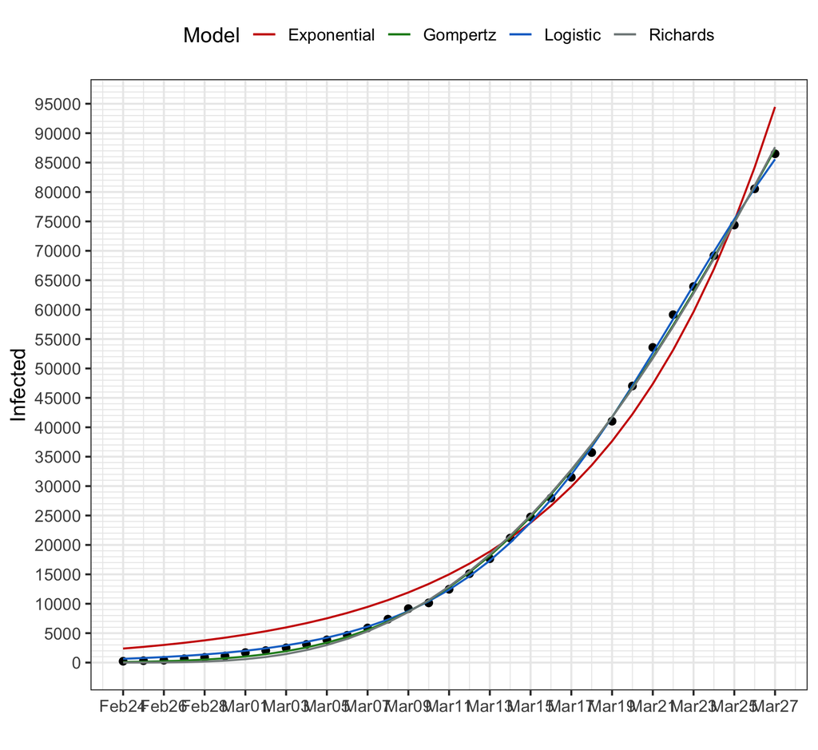

```r
ggplot(data, aes(x = date, y = y)) +
  geom_point() +
  geom_line(aes(y = fitted(mod1), color = "Exponential")) +
  geom_line(aes(y = fitted(mod2), color = "Logistic")) +
  geom_line(aes(y = fitted(mod3), color = "Gompertz")) +
  geom_line(aes(y = fitted(mod4), color = "Richards")) +
  labs(x = "", y = "Infected", color = "Model") +
  scale_color_manual(values = cols) +
  scale_y_continuous(breaks = seq(0, coef(mod2)[1], by = 5000),
                     minor_breaks = seq(0, coef(mod2)[1], by = 1000)) +
  scale_x_date(date_breaks = "2 day", date_labels =  "%b%d",
               minor_breaks = "1 day") +
  theme_bw() +
  theme(legend.position = "top")
```

## Predictions

### Point estimates

```r
df = data.frame(x = seq(min(data$x), max(data$x)+14))
df = cbind(df, date = as.Date(df$x, origin = data$date[1]-1),
               fit1 = predict(mod1, newdata = df),
               fit2 = predict(mod2, newdata = df),
               fit3 = predict(mod3, newdata = df),
               fit4 = predict(mod4, newdata = df))
ylim = c(0, max(df[,c("fit2", "fit3")]))
```

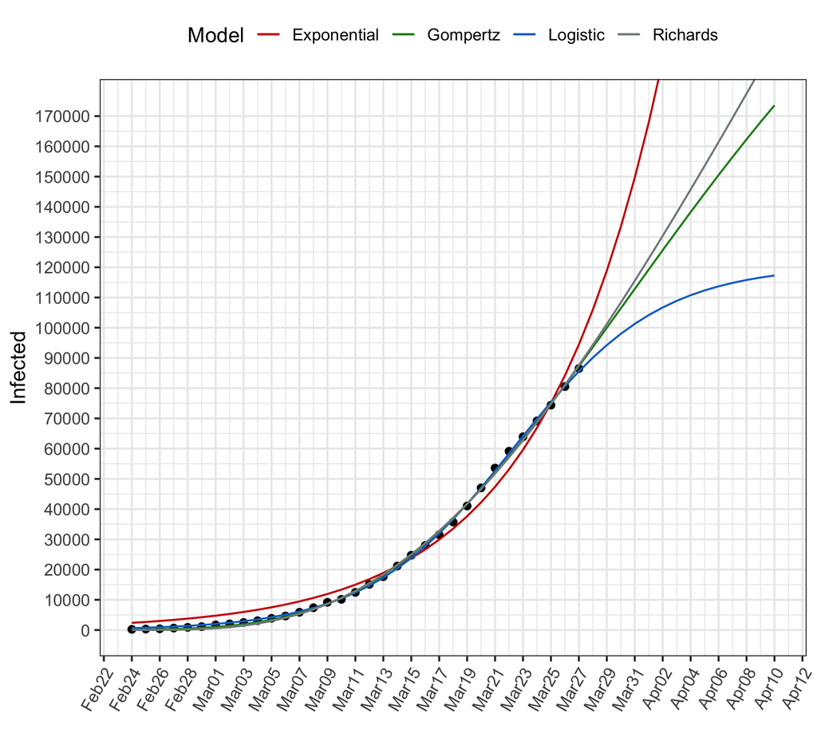

```r
ggplot(data, aes(x = date, y = y)) +
  geom_point() +
  geom_line(data = df, aes(x = date, y = fit1, color = "Exponential")) +
  geom_line(data = df, aes(x = date, y = fit2, color = "Logistic")) +
  geom_line(data = df, aes(x = date, y = fit3, color = "Gompertz")) +
  geom_line(data = df, aes(x = date, y = fit4, color = "Richards")) +
  coord_cartesian(ylim = ylim) +
  labs(x = "", y = "Infected", color = "Model") +
  scale_y_continuous(breaks = seq(0, max(ylim), by = 10000),
                     minor_breaks = seq(0, max(ylim), by = 5000)) +
  scale_x_date(date_breaks = "2 day", date_labels =  "%b%d",
               minor_breaks = "1 day") +
  scale_color_manual(values = cols) +
  theme_bw() +
  theme(legend.position = "top",
        axis.text.x = element_text(angle=60, hjust=1))
```

### Prediction intervals

```r
# compute prediction using Moving Block Bootstrap (MBB) for nls
df = data.frame(x = seq(min(data$x), max(data$x)+14))
df = cbind(df, date = as.Date(df$x, origin = data$date[1]-1))

pred1 = cbind(df, "fit" = predict(mod1, newdata = df))
pred1[df$x > max(data$x), c("lwr", "upr")] = predictMBB.nls(mod1, df[df$x > max(data$x),])[,2:3]

pred2 = cbind(df, "fit" = predict(mod2, newdata = df))
pred2[df$x > max(data$x), c("lwr", "upr")] = predictMBB.nls(mod2, df[df$x > max(data$x),])[,2:3]

pred3 = cbind(df, "fit" = predict(mod3, newdata = df))
pred3[df$x > max(data$x), c("lwr", "upr")] = predictMBB.nls(mod3, df[df$x > max(data$x),])[,2:3]

pred4 = cbind(df, "fit" = predict(mod4, newdata = df))
pred4[df$x > max(data$x), c("lwr", "upr")] = predictMBB.nls(mod4, df[df$x > max(data$x),])[,2:3]

# predictions for next day
pred = rbind(subset(pred1, x == max(data$x)+1, select = 2:5),
             subset(pred2, x == max(data$x)+1, select = 2:5),
             subset(pred3, x == max(data$x)+1, select = 2:5),
             subset(pred4, x == max(data$x)+1, select = 2:5))
print(pred, digits = 3)
##           date    fit   lwr    upr
## 34  2020-03-28 105972 96584 117991
## 341 2020-03-28  90112 88527  91466
## 342 2020-03-28  93592 91701  95749
## 343 2020-03-28  94336 91728  97420

ylim = c(0, max(pred2$upr, pred3$upr, na.rm=TRUE))
```

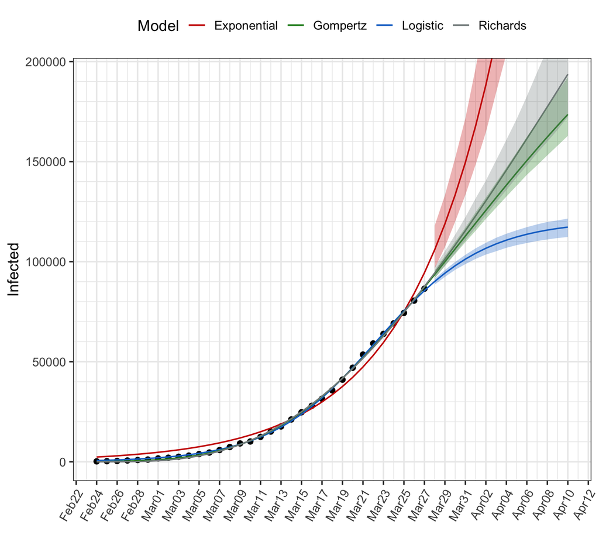

```r
ggplot(data, aes(x = date, y = y)) +
  geom_point() +
  geom_line(data = pred1, aes(x = date, y = fit, color = "Exponential")) +
  geom_line(data = pred2, aes(x = date, y = fit, color = "Logistic")) +
  geom_line(data = pred3, aes(x = date, y = fit, color = "Gompertz")) +
  geom_line(data = pred4, aes(x = date, y = fit, color = "Richards")) +
  geom_ribbon(data = pred1, aes(x = date, ymin = lwr, ymax = upr),
              inherit.aes = FALSE, fill = cols[1], alpha=0.3) +
  geom_ribbon(data = pred2, aes(x = date, ymin = lwr, ymax = upr),
              inherit.aes = FALSE, fill = cols[2], alpha=0.3) +
  geom_ribbon(data = pred3, aes(x = date, ymin = lwr, ymax = upr),
              inherit.aes = FALSE, fill = cols[3], alpha=0.3) +
  geom_ribbon(data = pred4, aes(x = date, ymin = lwr, ymax = upr),
              inherit.aes = FALSE, fill = cols[4], alpha=0.3) +
  coord_cartesian(ylim = c(0, max(ylim))) +
  labs(x = "", y = "Infected", color = "Model") +
  scale_y_continuous(minor_breaks = seq(0, max(ylim), by = 10000)) +
  scale_x_date(date_breaks = "2 day", date_labels =  "%b%d",
               minor_breaks = "1 day") +
  scale_color_manual(values = cols) +
  theme_bw() +
  theme(legend.position = "top",
        axis.text.x = element_text(angle=60, hjust=1))
```

# Modelling total deceased

```r
# create data for analysis
data = data.frame(date = COVID19IT$data,
                  y = COVID19IT$deceduti)
data$x = as.numeric(data$date) - min(as.numeric(data$date)) + 1
DT::datatable(data, options = list("pageLength" = 5))
```

|  | date | y | x |
| --- | --- | --- | --- |
| 1 | 2020-02-24 | 7 | 1 |
| 2 | 2020-02-25 | 10 | 2 |
| 3 | 2020-02-26 | 12 | 3 |
| 4 | 2020-02-27 | 17 | 4 |
| 5 | 2020-02-28 | 21 | 5 |
| 6 | 2020-02-29 | 29 | 6 |
| 7 | 2020-03-01 | 34 | 7 |
| 8 | 2020-03-02 | 52 | 8 |
| 9 | 2020-03-03 | 79 | 9 |
| 10 | 2020-03-04 | 107 | 10 |

[output cut: 23 more lines]

## Estimation

### Exponential

```r
mod1_start = lm(log(y) ~ x, data = data)
b = unname(coef(mod1_start))
start = list(th1 = log(b[1]), th2 = b[2])
exponential <- function(x, th1, th2) th1 * exp(th2 * x)
mod1 = nls(y ~ exponential(x, th1, th2), data = data, start = start)
summary(mod1)
##
## Formula: y ~ exponential(x, th1, th2)
##
## Parameters:
##       Estimate Std. Error t value     Pr(>|t|)
## th1 104.448043  13.517514   7.727 0.0000000102 ***
## th2   0.137545   0.004305  31.950      < 2e-16 ***
## ---
## Signif. codes:  0 '***' 0.001 '**' 0.01 '*' 0.05 '.' 0.1 ' ' 1
##
## Residual standard error: 309.5 on 31 degrees of freedom
##
## Number of iterations to convergence: 13
## Achieved convergence tolerance: 0.000007438
```

### Logistic

```r
mod2 = nls(y ~ SSlogis(x, Asym, xmid, scal), data = data)
summary(mod2)
##
## Formula: y ~ SSlogis(x, Asym, xmid, scal)
##
## Parameters:
##         Estimate  Std. Error t value Pr(>|t|)
## Asym 13590.48790   412.68254   32.93   <2e-16 ***
## xmid    29.92230     0.29867  100.19   <2e-16 ***
## scal     4.63997     0.09139   50.77   <2e-16 ***
## ---
## Signif. codes:  0 '***' 0.001 '**' 0.01 '*' 0.05 '.' 0.1 ' ' 1
##
## Residual standard error: 72.91 on 30 degrees of freedom
##
## Number of iterations to convergence: 0
## Achieved convergence tolerance: 0.000004805
```

### Gompertz

```r
mod3 = nls(y ~ SSgompertz(x, Asym, b2, b3), data = data)
# manually set starting values
# start = list(Asym = coef(mod2)[1])
# tmp = list(y = log(log(start$Asym) - log(data$y)), x = data$x)
# b = unname(coef(lm(y ~ x, data = tmp)))
# start = c(start, c(b2 = exp(b[1]), b3 = exp(b[2])))
# mod3 = nls(y ~ SSgompertz(x, Asym, b2, b3), data = data, start = start,
#            control = nls.control(maxiter = 10000))
summary(mod3)
##
## Formula: y ~ SSgompertz(x, Asym, b2, b3)
##
## Parameters:
##          Estimate   Std. Error t value        Pr(>|t|)
## Asym 41119.848627  3875.590481   10.61 0.0000000000113 ***
## b2      11.191983     0.302221   37.03         < 2e-16 ***
## b3       0.941034     0.002454  383.44         < 2e-16 ***
## ---
## Signif. codes:  0 '***' 0.001 '**' 0.01 '*' 0.05 '.' 0.1 ' ' 1
##
## Residual standard error: 61.39 on 30 degrees of freedom
##
## Number of iterations to convergence: 0
## Achieved convergence tolerance: 0.0000006113
```

### Richards

```r
richards <- function(x, th1, th2, th3) th1*(1 - exp(-th2*x))^th3
Loss  <- function(th, y, x) sum((y - richards(x, th[1], th[2], th[3]))^2)
start <- optim(par = c(coef(mod2)[1], 0.001, 1), fn = Loss,
               y = data$y, x = data$x)$par
names(start) <- c("th1", "th2", "th3")
mod4 = nls(y ~ richards(x, th1, th2, th3), data = data, start = start,
           # trace = TRUE, algorithm = "port",
           control = nls.control(maxiter = 1000))
summary(mod4)
##
## Formula: y ~ richards(x, th1, th2, th3)
##
## Parameters:
##         Estimate   Std. Error t value          Pr(>|t|)
## th1 85191.182808 22377.093779   3.807          0.000647 ***
## th2     0.034779     0.004657   7.469 0.000000025235317 ***
## th3     5.845584     0.419213  13.944 0.000000000000012 ***
## ---
## Signif. codes:  0 '***' 0.001 '**' 0.01 '*' 0.05 '.' 0.1 ' ' 1
##
## Residual standard error: 69.19 on 30 degrees of freedom
##
## Number of iterations to convergence: 20
## Achieved convergence tolerance: 0.000009828
```

### Models comparison

```r
models = list("Exponential model" = mod1,
              "Logistic model" = mod2,
              "Gompertz model" = mod3,
              "Richards model" = mod4)
tab = data.frame(loglik = sapply(models, logLik),
                 df = sapply(models, function(m) attr(logLik(m), "df")),
                 Rsquare = sapply(models, function(m)
                                  cor(data$y, fitted(m))^2),
                 AIC = sapply(models, AIC),
                 AICc = sapply(models, AICc),
                 BIC = sapply(models, BIC))
sel <- apply(tab[,4:6], 2, which.min)
tab$"" <- sapply(tabulate(sel, nbins = length(models))+1, symnum,
                 cutpoints = 0:4, symbols = c("", "*", "**", "***"))
knitr::kable(tab)
```

|  | loglik | df | Rsquare | AIC | AICc | BIC |  |
| --- | --- | --- | --- | --- | --- | --- | --- |
| Exponential model | -235.0449 | 3 | 0.9903845 | 476.0897 | 476.9173 | 480.5793 |  |
| Logistic model | -186.7980 | 4 | 0.9994247 | 381.5960 | 383.0246 | 387.5821 |  |
| Gompertz model | -181.1206 | 4 | 0.9995418 | 370.2413 | 371.6698 | 376.2273 | *** |
| Richards model | -185.0686 | 4 | 0.9994373 | 378.1372 | 379.5657 | 384.1232 |  |

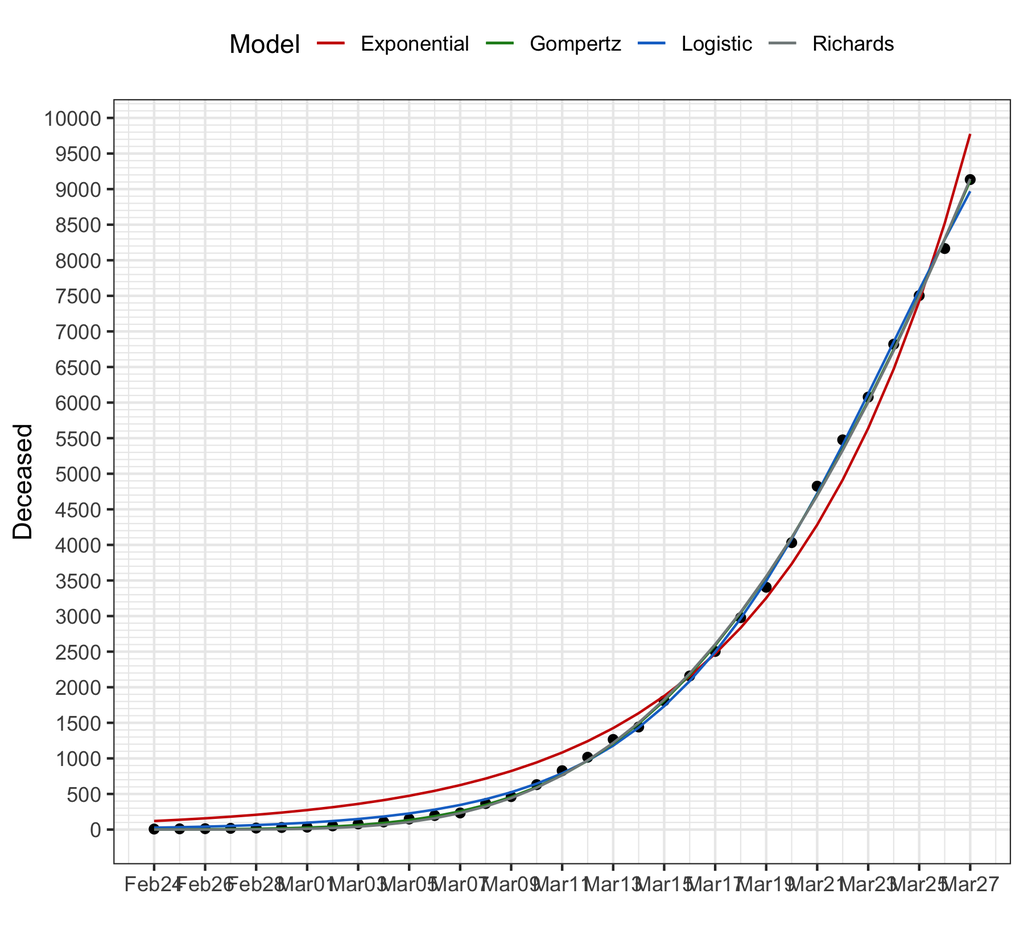

```r
ggplot(data, aes(x = date, y = y)) +
  geom_point() +
  geom_line(aes(y = fitted(mod1), color = "Exponential")) +
  geom_line(aes(y = fitted(mod2), color = "Logistic")) +
  geom_line(aes(y = fitted(mod3), color = "Gompertz")) +
  geom_line(aes(y = fitted(mod4), color = "Richards")) +
  labs(x = "", y = "Deceased", color = "Model") +
  scale_color_manual(values = cols) +
  scale_y_continuous(breaks = seq(0, coef(mod2)[1], by = 500),
                     minor_breaks = seq(0, coef(mod2)[1], by = 100)) +
  scale_x_date(date_breaks = "2 day", date_labels =  "%b%d",
               minor_breaks = "1 day") +
  theme_bw() +
  theme(legend.position = "top")
```

## Predictions

### Point estimates

```r
df = data.frame(x = seq(min(data$x), max(data$x)+14))
df = cbind(df, date = as.Date(df$x, origin = data$date[1]-1),
               fit1 = predict(mod1, newdata = df),
               fit2 = predict(mod2, newdata = df),
               fit3 = predict(mod3, newdata = df),
               fit4 = predict(mod4, newdata = df))
ylim = c(0, max(df[,-(1:3)]))
```

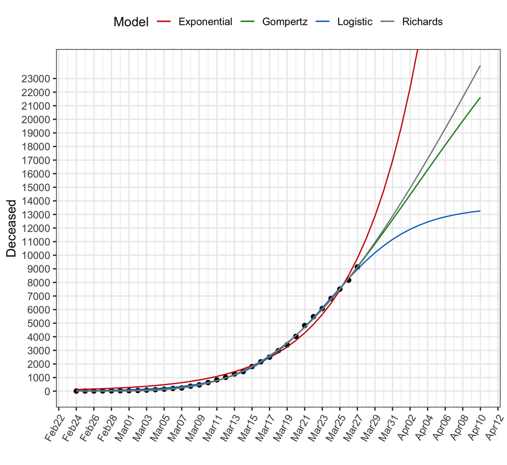

```r
ggplot(data, aes(x = date, y = y)) +
  geom_point() +
  geom_line(data = df, aes(x = date, y = fit1, color = "Exponential")) +
  geom_line(data = df, aes(x = date, y = fit2, color = "Logistic")) +
  geom_line(data = df, aes(x = date, y = fit3, color = "Gompertz")) +
  geom_line(data = df, aes(x = date, y = fit4, color = "Richards")) +
  coord_cartesian(ylim = ylim) +
  labs(x = "", y = "Deceased", color = "Model") +
  scale_y_continuous(breaks = seq(0, max(ylim), by = 1000),
                     minor_breaks = seq(0, max(ylim), by = 1000)) +
  scale_x_date(date_breaks = "2 day", date_labels =  "%b%d",
               minor_breaks = "1 day") +
  scale_color_manual(values = cols) +
  theme_bw() +
  theme(legend.position = "top",
        axis.text.x = element_text(angle=60, hjust=1))
```

### Prediction intervals

```r
# compute prediction using Moving Block Bootstrap (MBB) for nls
df = data.frame(x = seq(min(data$x), max(data$x)+14))
df = cbind(df, date = as.Date(df$x, origin = data$date[1]-1))

pred1 = cbind(df, "fit" = predict(mod1, newdata = df))
pred1[df$x > max(data$x), c("lwr", "upr")] = predictMBB.nls(mod1, df[df$x > max(data$x),])[,2:3]

pred2 = cbind(df, "fit" = predict(mod2, newdata = df))
pred2[df$x > max(data$x), c("lwr", "upr")] = predictMBB.nls(mod2, df[df$x > max(data$x),])[,2:3]

pred3 = cbind(df, "fit" = predict(mod3, newdata = df))
pred3[df$x > max(data$x), c("lwr", "upr")] = predictMBB.nls(mod3, df[df$x > max(data$x),])[,2:3]

pred4 = cbind(df, "fit" = predict(mod4, newdata = df))
pred4[df$x > max(data$x), c("lwr", "upr")] = predictMBB.nls(mod4, df[df$x > max(data$x),])[,2:3]

# predictions for next day
pred = rbind(subset(pred1, x == max(data$x)+1, select = 2:5),
             subset(pred2, x == max(data$x)+1, select = 2:5),
             subset(pred3, x == max(data$x)+1, select = 2:5),
             subset(pred4, x == max(data$x)+1, select = 2:5))
print(pred, digits = 3)
##           date   fit   lwr   upr
## 34  2020-03-28 11217 10365 12283
## 341 2020-03-28  9603  9358  9787
## 342 2020-03-28  9965  9761 10171
## 343 2020-03-28 10027  9799 10274

ylim = c(0, max(pred2$upr, pred3$upr, na.rm=TRUE))
```

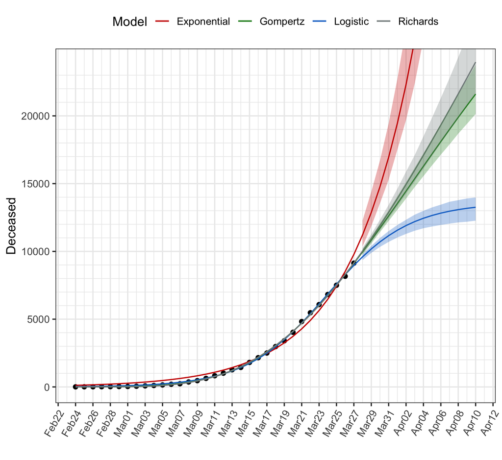

```r
ggplot(data, aes(x = date, y = y)) +
  geom_point() +
  geom_line(data = pred1, aes(x = date, y = fit, color = "Exponential")) +
  geom_line(data = pred2, aes(x = date, y = fit, color = "Logistic")) +
  geom_line(data = pred3, aes(x = date, y = fit, color = "Gompertz")) +
  geom_line(data = pred4, aes(x = date, y = fit, color = "Richards")) +
  geom_ribbon(data = pred1, aes(x = date, ymin = lwr, ymax = upr),
              inherit.aes = FALSE, fill = cols[1], alpha=0.3) +
  geom_ribbon(data = pred2, aes(x = date, ymin = lwr, ymax = upr),
              inherit.aes = FALSE, fill = cols[2], alpha=0.3) +
  geom_ribbon(data = pred3, aes(x = date, ymin = lwr, ymax = upr),
              inherit.aes = FALSE, fill = cols[3], alpha=0.3) +
  geom_ribbon(data = pred4, aes(x = date, ymin = lwr, ymax = upr),
              inherit.aes = FALSE, fill = cols[4], alpha=0.3) +
  coord_cartesian(ylim = c(0, max(ylim))) +
  labs(x = "", y = "Deceased", color = "Model") +
  scale_y_continuous(minor_breaks = seq(0, max(ylim), by = 1000)) +
  scale_x_date(date_breaks = "2 day", date_labels =  "%b%d",
               minor_breaks = "1 day") +
  scale_color_manual(values = cols) +
  theme_bw() +
  theme(legend.position = "top",
        axis.text.x = element_text(angle=60, hjust=1))
```

# Modelling recovered

```r
# create data for analysis
data = data.frame(date = COVID19IT$data,
                  y = COVID19IT$dimessi_guariti)
data$x = as.numeric(data$date) - min(as.numeric(data$date)) + 1
DT::datatable(data, options = list("pageLength" = 5))
```

|  | date | y | x |
| --- | --- | --- | --- |
| 1 | 2020-02-24 | 1 | 1 |
| 2 | 2020-02-25 | 1 | 2 |
| 3 | 2020-02-26 | 3 | 3 |
| 4 | 2020-02-27 | 45 | 4 |
| 5 | 2020-02-28 | 46 | 5 |
| 6 | 2020-02-29 | 50 | 6 |
| 7 | 2020-03-01 | 83 | 7 |
| 8 | 2020-03-02 | 149 | 8 |
| 9 | 2020-03-03 | 160 | 9 |
| 10 | 2020-03-04 | 276 | 10 |

[output cut: 23 more lines]

## Estimation

### Exponential

```r
mod1_start = lm(log(y) ~ x, data = data)
b = unname(coef(mod1_start))
start = list(th1 = log(b[1]), th2 = b[2])
exponential <- function(x, th1, th2) th1 * exp(th2 * x)
mod1 = nls(y ~ exponential(x, th1, th2), data = data, start = start)
summary(mod1)
##
## Formula: y ~ exponential(x, th1, th2)
##
## Parameters:
##       Estimate Std. Error t value      Pr(>|t|)
## th1 151.655035  18.908430    8.02 0.00000000468 ***
## th2   0.132394   0.004164   31.79       < 2e-16 ***
## ---
## Signif. codes:  0 '***' 0.001 '**' 0.01 '*' 0.05 '.' 0.1 ' ' 1
##
## Residual standard error: 386.9 on 31 degrees of freedom
##
## Number of iterations to convergence: 17
## Achieved convergence tolerance: 0.000001852
```

### Logistic

```r
mod2 = nls(y ~ SSlogis(x, Asym, xmid, scal), data = data)
summary(mod2)
##
## Formula: y ~ SSlogis(x, Asym, xmid, scal)
##
## Parameters:
##        Estimate Std. Error t value Pr(>|t|)
## Asym 16713.0209   656.7712   25.45   <2e-16 ***
## xmid    29.8420     0.3995   74.69   <2e-16 ***
## scal     4.8051     0.1217   39.48   <2e-16 ***
## ---
## Signif. codes:  0 '***' 0.001 '**' 0.01 '*' 0.05 '.' 0.1 ' ' 1
##
## Residual standard error: 116.7 on 30 degrees of freedom
##
## Number of iterations to convergence: 0
## Achieved convergence tolerance: 0.000001341
```

### Gompertz

```r
mod3 = nls(y ~ SSgompertz(x, Asym, b2, b3), data = data)
summary(mod3)
##
## Formula: y ~ SSgompertz(x, Asym, b2, b3)
##
## Parameters:
##         Estimate  Std. Error t value  Pr(>|t|)
## Asym 55926.42882 11327.02053   4.937 0.0000278 ***
## b2      10.24157     0.44783  22.869   < 2e-16 ***
## b3       0.94541     0.00466 202.859   < 2e-16 ***
## ---
## Signif. codes:  0 '***' 0.001 '**' 0.01 '*' 0.05 '.' 0.1 ' ' 1
##
## Residual standard error: 151.5 on 30 degrees of freedom
##
## Number of iterations to convergence: 0
## Achieved convergence tolerance: 0.000001401
```

### Richards

```r
richards <- function(x, th1, th2, th3) th1*(1 - exp(-th2*x))^th3
Loss  <- function(th, y, x) sum((y - richards(x, th[1], th[2], th[3]))^2)
start <- optim(par = c(coef(mod2)[1], 0.001, 1), fn = Loss,
               y = data$y, x = data$x)$par
names(start) <- c("th1", "th2", "th3")
mod4 = nls(y ~ richards(x, th1, th2, th3), data = data, start = start,
           # trace = TRUE, # algorithm = "port",
           control = nls.control(maxiter = 1000))
summary(mod4)
##
## Formula: y ~ richards(x, th1, th2, th3)
##
## Parameters:
##          Estimate    Std. Error t value     Pr(>|t|)
## th1 147651.937929  99804.504918   1.479      0.14946
## th2      0.027672      0.009151   3.024      0.00507 **
## th3      5.019664      0.682760   7.352 0.0000000344 ***
## ---
## Signif. codes:  0 '***' 0.001 '**' 0.01 '*' 0.05 '.' 0.1 ' ' 1
##
## Residual standard error: 168.2 on 30 degrees of freedom
##
## Number of iterations to convergence: 27
## Achieved convergence tolerance: 0.000009408
```

### Models comparison

```r
models = list("Exponential model" = mod1,
              "Logistic model" = mod2,
              "Gompertz model" = mod3,
              "Richards model" = mod4)
tab = data.frame(loglik = sapply(models, logLik),
                 df = sapply(models, function(m) attr(logLik(m), "df")),
                 Rsquare = sapply(models, function(m)
                                  cor(data$y, fitted(m))^2),
                 AIC = sapply(models, AIC),
                 AICc = sapply(models, AICc),
                 BIC = sapply(models, BIC))
sel <- apply(tab[,4:6], 2, which.min)
tab$"" <- sapply(tabulate(sel, nbins = length(models))+1, symnum,
                 cutpoints = 0:4, symbols = c("", "*", "**", "***"))
knitr::kable(tab)
```

|  | loglik | df | Rsquare | AIC | AICc | BIC |  |
| --- | --- | --- | --- | --- | --- | --- | --- |
| Exponential model | -242.4119 | 3 | 0.9895195 | 490.8238 | 491.6514 | 495.3134 |  |
| Logistic model | -202.3168 | 4 | 0.9988907 | 412.6336 | 414.0622 | 418.6196 | *** |
| Gompertz model | -210.9296 | 4 | 0.9981873 | 429.8593 | 431.2879 | 435.8453 |  |
| Richards model | -214.3902 | 4 | 0.9978366 | 436.7804 | 438.2090 | 442.7664 |  |

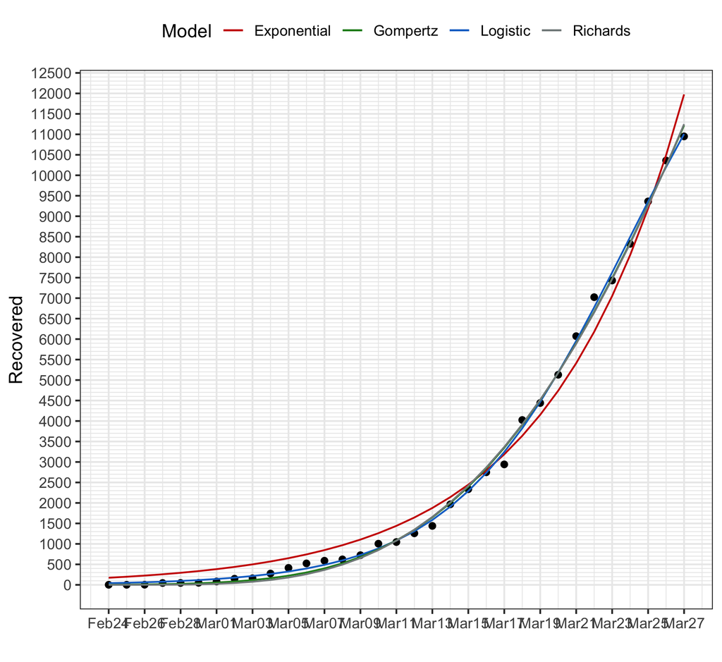

```r
ggplot(data, aes(x = date, y = y)) +
  geom_point() +
  geom_line(aes(y = fitted(mod1), color = "Exponential")) +
  geom_line(aes(y = fitted(mod2), color = "Logistic")) +
  geom_line(aes(y = fitted(mod3), color = "Gompertz")) +
  geom_line(aes(y = fitted(mod4), color = "Richards")) +
  labs(x = "", y = "Recovered", color = "Model") +
  scale_color_manual(values = cols) +
  scale_y_continuous(breaks = seq(0, coef(mod2)[1], by = 500),
                     minor_breaks = seq(0, coef(mod2)[1], by = 100)) +
  scale_x_date(date_breaks = "2 day", date_labels =  "%b%d",
               minor_breaks = "1 day") +
  theme_bw() +
  theme(legend.position = "top")
```

## Predictions

### Point estimates

```r
df = data.frame(x = seq(min(data$x), max(data$x)+14))
df = cbind(df, date = as.Date(df$x, origin = data$date[1]-1),
               fit1 = predict(mod1, newdata = df),
               fit2 = predict(mod2, newdata = df),
               fit3 = predict(mod3, newdata = df),
               fit4 = predict(mod4, newdata = df))
ylim = c(0, max(df[,-(1:3)]))
```

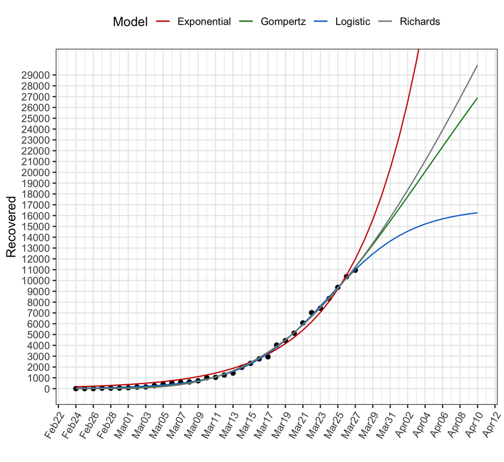

```r
ggplot(data, aes(x = date, y = y)) +
  geom_point() +
  geom_line(data = df, aes(x = date, y = fit1, color = "Exponential")) +
  geom_line(data = df, aes(x = date, y = fit2, color = "Logistic")) +
  geom_line(data = df, aes(x = date, y = fit3, color = "Gompertz")) +
  geom_line(data = df, aes(x = date, y = fit4, color = "Richards")) +
  coord_cartesian(ylim = ylim) +
  labs(x = "", y = "Recovered", color = "Model") +
  scale_y_continuous(breaks = seq(0, max(ylim), by = 1000),
                     minor_breaks = seq(0, max(ylim), by = 1000)) +
  scale_x_date(date_breaks = "2 day", date_labels =  "%b%d",
               minor_breaks = "1 day") +
  scale_color_manual(values = cols) +
  theme_bw() +
  theme(legend.position = "top",
        axis.text.x = element_text(angle=60, hjust=1))
```

### Prediction intervals

```r
# compute prediction using Moving Block Bootstrap (MBB) for nls
df = data.frame(x = seq(min(data$x), max(data$x)+14))
df = cbind(df, date = as.Date(df$x, origin = data$date[1]-1))

pred1 = cbind(df, "fit" = predict(mod1, newdata = df))
pred1[df$x > max(data$x), c("lwr", "upr")] = predictMBB.nls(mod1, df[df$x > max(data$x),])[,2:3]

pred2 = cbind(df, "fit" = predict(mod2, newdata = df))
pred2[df$x > max(data$x), c("lwr", "upr")] = predictMBB.nls(mod2, df[df$x > max(data$x),])[,2:3]

pred3 = cbind(df, "fit" = predict(mod3, newdata = df))
pred3[df$x > max(data$x), c("lwr", "upr")] = predictMBB.nls(mod3, df[df$x > max(data$x),])[,2:3]

pred4 = cbind(df, "fit" = predict(mod4, newdata = df))
pred4[df$x > max(data$x), c("lwr", "upr")] = predictMBB.nls(mod4, df[df$x > max(data$x),])[,2:3]

# predictions for next day
pred = rbind(subset(pred1, x == max(data$x)+1, select = 2:5),
             subset(pred2, x == max(data$x)+1, select = 2:5),
             subset(pred3, x == max(data$x)+1, select = 2:5),
             subset(pred4, x == max(data$x)+1, select = 2:5))
print(pred, digits = 3)
##           date   fit   lwr   upr
## 34  2020-03-28 13670 12660 15001
## 341 2020-03-28 11762 11433 12051
## 342 2020-03-28 12247 11814 12738
## 343 2020-03-28 12320 11844 12882

ylim = c(0, max(pred2$upr, pred3$upr, na.rm=TRUE))
```

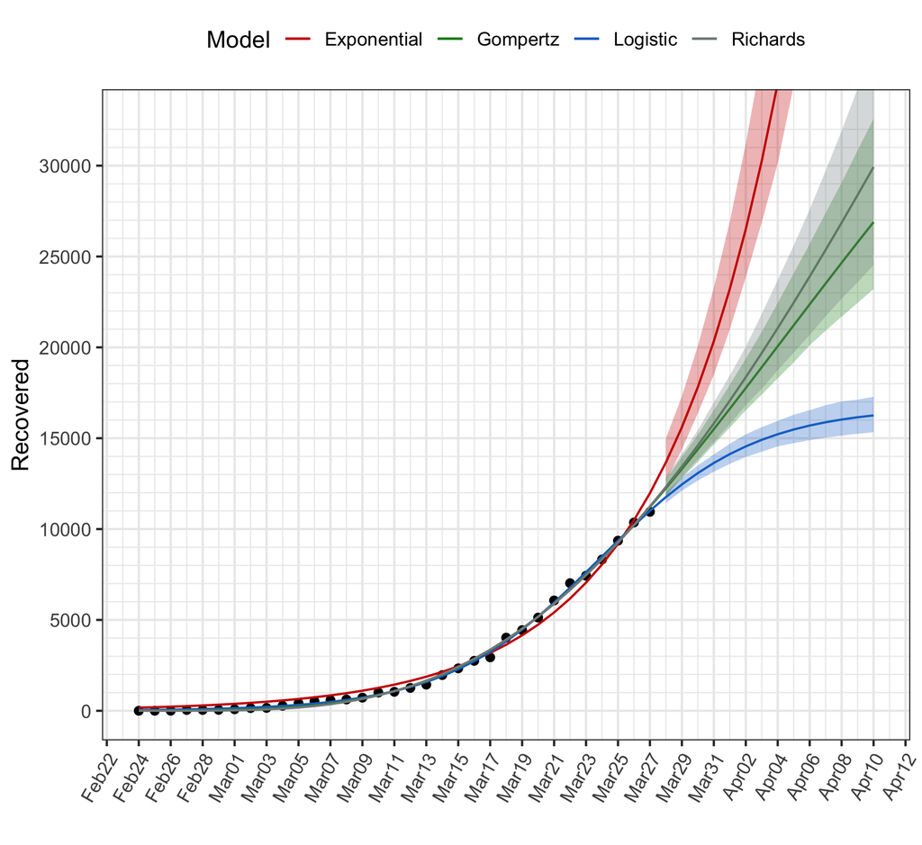

```r
ggplot(data, aes(x = date, y = y)) +
  geom_point() +
  geom_line(data = pred1, aes(x = date, y = fit, color = "Exponential")) +
  geom_line(data = pred2, aes(x = date, y = fit, color = "Logistic")) +
  geom_line(data = pred3, aes(x = date, y = fit, color = "Gompertz")) +
  geom_line(data = pred4, aes(x = date, y = fit, color = "Richards")) +
  geom_ribbon(data = pred1, aes(x = date, ymin = lwr, ymax = upr),
              inherit.aes = FALSE, fill = cols[1], alpha=0.3) +
  geom_ribbon(data = pred2, aes(x = date, ymin = lwr, ymax = upr),
              inherit.aes = FALSE, fill = cols[2], alpha=0.3) +
  geom_ribbon(data = pred3, aes(x = date, ymin = lwr, ymax = upr),
              inherit.aes = FALSE, fill = cols[3], alpha=0.3) +
  geom_ribbon(data = pred4, aes(x = date, ymin = lwr, ymax = upr),
              inherit.aes = FALSE, fill = cols[4], alpha=0.3) +
  coord_cartesian(ylim = c(0, max(ylim))) +
  labs(x = "", y = "Recovered", color = "Model") +
  scale_y_continuous(breaks = seq(0, max(ylim), by = 5000),
                     minor_breaks = seq(0, max(ylim), by = 1000)) +
  scale_x_date(date_breaks = "2 day", date_labels =  "%b%d",
               minor_breaks = "1 day") +
  scale_color_manual(values = cols) +
  theme_bw() +
  theme(legend.position = "top",
        axis.text.x = element_text(angle=60, hjust=1))
```